# RGGI Data Analysis

Eric Scheier

3/16/2021

```r
read_then_csv <- function(sheet, path) {
  pathbase <- path %>%
    basename() %>%
    tools::file_path_sans_ext()
  path %>%
    read_excel(sheet = sheet, col_names = FALSE, col_types = "text") %>%
    write_csv(paste0("data/",sheet, ".csv"))
}

extract_all_sheets <- function(path){
  path %>%
    readxl::excel_sheets() %>%
    set_names() %>%
    map(read_then_csv, path = path)
}

download_current_egrid <- function(url=NULL){
  temp <- tempfile()
  download.file(url,temp,mode="wb", method="libcurl")
  # mode = 'wb'
  # path <- temp
  extract_all_sheets(path=temp)
}

get_state_egrid <- function(year=2019, relevant_file_path=NULL){
  if(is.null(relevant_file_path)){
    # https://stackoverflow.com/questions/44009924/getting-last-two-digits-from-numeric-in-r
    year_code <- format(as.Date(sprintf('%d-01-01', year)), '%y')
    file_pattern <- paste0("*.ST",year_code,".csv") #".*ST[0-9]*.csv"
    relevant_file_path <- list.files(path="data",pattern=file_pattern,
                                     full.names=TRUE,ignore.case=TRUE)
  }
  message("reading ",relevant_file_path)
  # if(!file.exists(relevant_file_path)){
  #   download_current_egrid()
  # }
  retry <- TRUE
  skip_to_line <- 0
  while(retry){
    state_egrid <- read_csv(relevant_file_path, skip=skip_to_line)
    fips_row <- which(apply(state_egrid, 1, function(x) {any(grepl(x, pattern = "FIPS")) }))
    fips_row <- fips_row[length(fips_row)]
    if(length(fips_row)>0 && fips_row != skip_to_line){
      skip_to_line <- fips_row
    } else {
      retry <- FALSE
    }
  }

  names(state_egrid) <- sub("\n.*","",names(state_egrid))

  return(state_egrid)
}

download_historical_egrid <- function(url=NULL){
  temp <- tempfile()
  download.file(url,temp)
  unzip(zipfile=temp,exdir="data")
  unlink(temp)
}

# function to get the year from the filename
year_from_file <- function(file_name){
  current_year <- as.numeric(format(Sys.Date(),"%y"))
  file_year <- as.numeric(gsub("[^\\d]+", "",
                               file_name, perl=TRUE))
  full_file_year <- ifelse(file_year>current_year,
                           1900+file_year,
                           2000+file_year)
  return(full_file_year)
}
```

```r
historical_data_url <- "https://www.epa.gov/sites/production/files/2020-01/egrid2018_historical_files_since_1996.zip"
data_url_2018 <- "https://www.epa.gov/sites/production/files/2020-03/egrid2018_data_v2.xlsx"
data_url_2019 <- "https://www.epa.gov/sites/production/files/2021-02/egrid2019_data.xlsx"
```

We are interested in understanding the CO2 emissions intensity of electricity generated and consumed in member states of the Regional Greenhouse Gas Initiative (RGGI) before and during their participation in RGGI.

The data for making this assessment is available from the Environmental Protection Agency (EPA) through its Emissions & Generation Resource Integrated Database (eGRID).

We are interested in the following variables for our analysis:

- PSTATABB: The state abbreviation for easy sorting and viewing
- YEAR: which year the data was collected by the EPA (we must infer this from the data filenames)
- STNGENAN: State annual net generation (MWh)
- STCO2AN: State annual CO2 emissions (tons)
- STCO2RTA: State average annual CO2 output emission rate (lbs/MWh)

```r
if(!file.exists("egrid_selected_data_all_years.csv")){
  if (!dir.exists("data")) {dir.create("data")}

  download_current_egrid(url=data_url_2019)
  download_current_egrid(url=data_url_2018)
  download_historical_egrid(url=historical_data_url)

  historical_files <- list.files(path="data",
                                 pattern="^egrid.*?_(location|data|aggregation)(|_v2)\\.xls",
                                 full.names=TRUE,ignore.case=TRUE)

  lapply(historical_files, extract_all_sheets)

  state_files <- list.files(path="data",
             pattern=".*ST[0-9]*.csv",
             full.names = TRUE,ignore.case=TRUE)

  desired_columns <- c("state"="PSTATABB",
                       "generation_MWh"="STNGENAN",
                       "emissions_tons"="STCO2AN",
                       "emission_rate_lbs_per_MWh"="STCO2RTA")

  # https://stackoverflow.com/questions/63808658/combining-multiple-csv-files-together-in-an-r-loop
  new_data <- purrr::map_df(state_files, function(x) {
    mydata <- get_state_egrid(year=NULL,
                              relevant_file_path = x)
    mydata <- mydata[,desired_columns]
    mydata %>%
      mutate(year = year_from_file(x))
  }) %>%
    rename(all_of(desired_columns))

  write_csv(new_data,"egrid_selected_data_all_years.csv")
}
```

```r
egrid_data <- read_csv("egrid_selected_data_all_years.csv")
rggi_states <- c("CT",
                 "DE",
                 "ME",
                 "MD",
                 "MA",
                 "NH",
                 "NY",
                 "RI",
                 "VT")
rggi_initiation_year <- 2009

control_periods <- data.frame(list(
  "Period"=as.character(c(5,4,3,2,1)),
  "Start"=c(2021,2018,2015,2012,2009),
  "End"=c(2023,2020,2017,2014,2011)))

states_of_interest <- "NC" #c("NC","CA")
```

CT, DE, ME, MD, MA, NH, NY, RI, VT have been members of RGGI since its initiation in 2009. We are interested to compare the performance of all other states with the RGGI members and our state of interest: NC

```r
egrid_data$is_rggi <- ifelse(egrid_data$state %in% rggi_states, "RGGI", "Other")

egrid_data$is_rggi <- ifelse(egrid_data$state %in% states_of_interest, egrid_data$state, egrid_data$is_rggi)

egrid_data$is_rggi <- forcats::as_factor(egrid_data$is_rggi)
```

```r
grouped_emissions_rates <- egrid_data %>%
  group_by(is_rggi,year) %>%
  summarise(emissions_rate=weighted.mean(
    x=emission_rate_lbs_per_MWh,
    w=generation_MWh)) %>% ungroup()
```

```r
grouped_emissions_rates$during_rggi <- ifelse(
  grouped_emissions_rates$year<min(control_periods$Start),
  "Before",
  "During")

start_year <- grouped_emissions_rates[grouped_emissions_rates$year==min(control_periods$Start),]
start_year$during_rggi <- "Before"
graph_grouped_emissions_rates <- rbind(grouped_emissions_rates, start_year)
```

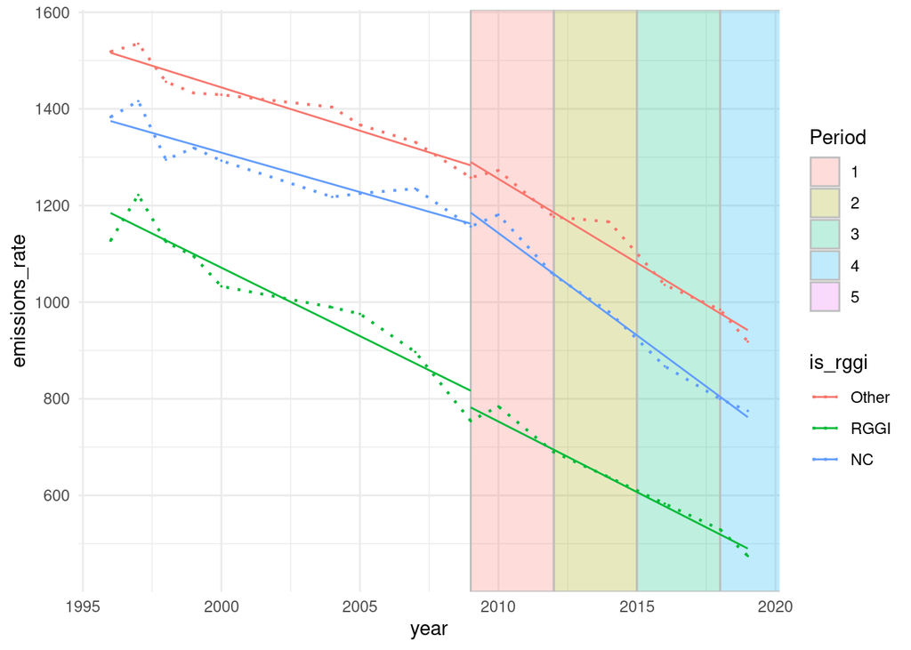

```r
# title
# y axis label
# x axis label
# x axis ticks
# Period legend title
# period legend labels
# is_rggi legend label
# remove out of scope rggi period

ggplot(data=graph_grouped_emissions_rates, aes(x=year,
                            y=emissions_rate,
                            color=is_rggi)) +
  geom_rect(data = control_periods,
            aes(xmin = Start,
                xmax = End+1,
                ymin = -Inf,
                ymax = Inf,
                fill = Period
                ),
            alpha = 0.25,
            color = "gray", size = .5,
            inherit.aes=FALSE) +
  geom_line(inherit.aes = TRUE,
            linetype="dotted",
            size=0.75) +
  geom_point(size=FALSE) +
  geom_smooth(aes(group=interaction(is_rggi,during_rggi)),
              formula=y~x,
              method = "lm",
              fill = NA,
              size=0.5,
              linetype="solid") +
  # geom_smooth(aes(group=is_rggi),
  #             fill=NA,
  #             method="lm") +
  theme_minimal() +
  coord_cartesian(
    xlim=c(
      min(egrid_data$year),
      max(egrid_data$year)))
```

```r
final_year_before_rggi <- max(
  unique(
    grouped_emissions_rates$year[
      grouped_emissions_rates$year<min(control_periods$Start)
      ]))

start_rggi_rate <- as.numeric(grouped_emissions_rates[grouped_emissions_rates$year==
                                       final_year_before_rggi &
                          grouped_emissions_rates$is_rggi=="RGGI",
                        "emissions_rate"])
end_rggi_rate <- as.numeric(grouped_emissions_rates[grouped_emissions_rates$year==
                                       max(grouped_emissions_rates$year) &
                          grouped_emissions_rates$is_rggi=="RGGI",
                        "emissions_rate"])

rggi_change <- (start_rggi_rate - end_rggi_rate)/start_rggi_rate


start_soi_rate <- as.numeric(grouped_emissions_rates[grouped_emissions_rates$year==
                                       final_year_before_rggi &
                          grouped_emissions_rates$is_rggi %in% states_of_interest,
                        "emissions_rate"])
end_soi_rate <- as.numeric(grouped_emissions_rates[grouped_emissions_rates$year==
                                       max(grouped_emissions_rates$year) &
                          grouped_emissions_rates$is_rggi %in% states_of_interest,
                        "emissions_rate"])

soi_change <- (start_soi_rate - end_soi_rate)/start_soi_rate

start_other_rate <- as.numeric(grouped_emissions_rates[grouped_emissions_rates$year==
                                       final_year_before_rggi &
                          grouped_emissions_rates$is_rggi=="Other",
                        "emissions_rate"])
end_other_rate <- as.numeric(grouped_emissions_rates[grouped_emissions_rates$year==
                                       max(grouped_emissions_rates$year) &
                          grouped_emissions_rates$is_rggi=="Other",
                        "emissions_rate"])

other_change <- (start_other_rate - end_other_rate)/start_other_rate
```

Whereas, the carbon dioxide emissions rate of the Regional Greenhouse Gas Initative (RGGI) member states’ electricity generation as measured by the Environmental Protection Agency’s Emissions & Generation Resource Integrated Database (EPA eGRID) in 2007, the final year of measurement prior to the start of the Initiative in 2009, was 897 pounds of carbon dioxide per megawatt-hour of electricity.

Whereas, the carbon dioxide emissions rate of North Carolina’s electricity generation as measured by EPA eGRID in the year 2007 was 1235 pounds of carbon dioxide per megawatt-hour of electricity.

Whereas, the carbon dioxide emissions rate of the RGGI member states’ electricity generation as most recently measured by EPA eGRID in the year 2019 is 475 pounds of carbon dioxide per megawatt-hour of electricity.

Whereas, the carbon dioxide emissions rate of North Carolina’s electricity generation as most recently measured by EPA eGRID in the year 2019 is 775 pounds of carbon dioxide per megawatt-hour of electricity.

Whereas, according to EPA eGRID, the carbon dioxide emissions rate of RGGI member states’ electricity generation has decreased by 47% since their initiation of the program in 2009.

Whereas, according to EPA eGRID, the carbon dioxide emissions rate of North Carolina’s electricity generation has decreased by 37% since 2009.

Whereas, according to EPA eGRID, the carbon dioxide emissions rate of North Carolina’s electricity generation is 1.6 times higher than that of the RGGI member states.